# ResNet Implementation

Kurz-Erklärung:

- ResNet = Regelmäßige Layer-Skips: Ein Convolutional Encoder-Decoder (bzw Bottleneck) Block erhält als Eingabe die addierten Ausgaben der beiden vorherigen Blöcke.
- ResNeXt = ResNet aber mit mehreren separaten Streams: Die Eingabe wird intern mit mehreren kleineren Layer parallel verarbeitet und später für den Layer-Skip zusammengeführt.

[figure not shown]

Grafik von Xie et al, "Aggregated Residual Transformations for Deep Neural Networks", 2017, arXiv:1611.05431v2

## Training

ResNet wird mittlerweile von Keras als fertige Architektur angeboten.

```python
from tensorflow.keras.applications import ResNet50V2

model = ResNet50V2()  # weights=None,classes=labels_amount)

# https://keras.rstudio.com/reference/compile.html
model.compile(
    optimizer='adam',
    loss='categorical_crossentropy',
    metrics=['accuracy']
)
```

```python
model.summary()
```

```
Model: "resnet50v2"
__________________________________________________________________________________________________
Layer (type)                    Output Shape         Param #     Connected to
==================================================================================================
input_1 (InputLayer)            [(None, 224, 224, 3) 0
__________________________________________________________________________________________________
conv1_pad (ZeroPadding2D)       (None, 230, 230, 3)  0           input_1[0][0]
__________________________________________________________________________________________________
conv1_conv (Conv2D)             (None, 112, 112, 64) 9472        conv1_pad[0][0]
__________________________________________________________________________________________________
pool1_pad (ZeroPadding2D)       (None, 114, 114, 64) 0           conv1_conv[0][0]
__________________________________________________________________________________________________
pool1_pool (MaxPooling2D)       (None, 56, 56, 64)   0           pool1_pad[0][0]
__________________________________________________________________________________________________
conv2_block1_preact_bn (BatchNo (None, 56, 56, 64)   256         pool1_pool[0][0]
__________________________________________________________________________________________________
conv2_block1_preact_relu (Activ (None, 56, 56, 64)   0           conv2_block1_preact_bn[0][0]
__________________________________________________________________________________________________
conv2_block1_1_conv (Conv2D)    (None, 56, 56, 64)   4096        conv2_block1_preact_relu[0][0]
__________________________________________________________________________________________________
conv2_block1_1_bn (BatchNormali (None, 56, 56, 64)   256         conv2_block1_1_conv[0][0]
__________________________________________________________________________________________________
conv2_block1_1_relu (Activation (None, 56, 56, 64)   0           conv2_block1_1_bn[0][0]
__________________________________________________________________________________________________
conv2_block1_2_pad (ZeroPadding (None, 58, 58, 64)   0           conv2_block1_1_relu[0][0]
__________________________________________________________________________________________________
conv2_block1_2_conv (Conv2D)    (None, 56, 56, 64)   36864       conv2_block1_2_pad[0][0]
__________________________________________________________________________________________________
conv2_block1_2_bn (BatchNormali (None, 56, 56, 64)   256         conv2_block1_2_conv[0][0]
__________________________________________________________________________________________________
conv2_block1_2_relu (Activation (None, 56, 56, 64)   0           conv2_block1_2_bn[0][0]
__________________________________________________________________________________________________
conv2_block1_0_conv (Conv2D)    (None, 56, 56, 256)  16640       conv2_block1_preact_relu[0][0]
__________________________________________________________________________________________________
conv2_block1_3_conv (Conv2D)    (None, 56, 56, 256)  16640       conv2_block1_2_relu[0][0]
__________________________________________________________________________________________________
conv2_block1_out (Add)          (None, 56, 56, 256)  0           conv2_block1_0_conv[0][0]
                                                                 conv2_block1_3_conv[0][0]
__________________________________________________________________________________________________
conv2_block2_preact_bn (BatchNo (None, 56, 56, 256)  1024        conv2_block1_out[0][0]
```

[output cut: 353 more lines]

```
conv5_block3_out (Add)          (None, 7, 7, 2048)   0           conv5_block2_out[0][0]
                                                                 conv5_block3_3_conv[0][0]
__________________________________________________________________________________________________
post_bn (BatchNormalization)    (None, 7, 7, 2048)   8192        conv5_block3_out[0][0]
__________________________________________________________________________________________________
post_relu (Activation)          (None, 7, 7, 2048)   0           post_bn[0][0]
__________________________________________________________________________________________________
avg_pool (GlobalAveragePooling2 (None, 2048)         0           post_relu[0][0]
__________________________________________________________________________________________________
predictions (Dense)             (None, 1000)         2049000     avg_pool[0][0]
==================================================================================================
Total params: 25,613,800
Trainable params: 25,568,360
Non-trainable params: 45,440
__________________________________________________________________________________________________
```

Da es sehr viele (25,568,360) trainierbare Parameter gibt, dauert das Training dementsprechend lange. Der Datensatz wird auf 10,000 Samples reduziert, damit das lokale Training einer Periode nicht länger als eine halbe Stunde dauert.

Damit nicht jedes mal neu trainiert werden muss, können stattdessen an dieser Stelle Gewichte geladen werden. Der Trainingsverlauf kann auch gespeichert werden.

```python
model.load_weights('data/resnet_weights.h5')

import pickle
with open('data/resnet_history.pickle', 'rb') as file_pi:
    history = pickle.load(file_pi)
```

Das Training kann ruhig im Hintergrund laufen. Es sind zwar nur wenige Epochen vorgesehen, die dauern aber dennoch 2-3 Stunden (mit schwacher GPU).

```python
callback = model.fit(X_train, y_train, epochs = 10, validation_split=0.2)
```

```
WARNING:tensorflow:Model was constructed with shape (None, 224, 224, 3) for input Tensor("input_1:0", shape=(None, 224, 224, 3), dtype=float32), but it was called on an input with incompatible shape (32, 28, 28, 3).
WARNING:tensorflow:Model was constructed with shape (None, 224, 224, 3) for input Tensor("input_1:0", shape=(None, 224, 224, 3), dtype=float32), but it was called on an input with incompatible shape (32, 28, 28, 3).
```

Die Gewichte und Trainingsverlauf werden anschließend gespeichert, um wie zuvor erwähnt wiederverwendet werden zu können.

```python
model.save_weights('data/resnet_weights.h5')

history = callback.history
# https://stackoverflow.com/a/44674337
import pickle
with open('data/resnet_history.pickle', 'wb') as file_pi:
    pickle.dump(history, file_pi)
```

## ResNet Überprüfen

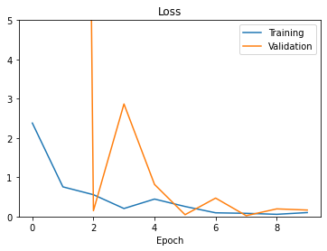

```python
import matplotlib.pyplot as plt

plt.plot(history['loss'], label='Training')
plt.plot(history['val_loss'], label='Validation')
plt.title('Loss')
plt.xlabel('Epoch')
plt.gca().set_ylim([0, 5]) # Sonderfall, Spitze abschneiden
plt.legend()
plt.show()
```

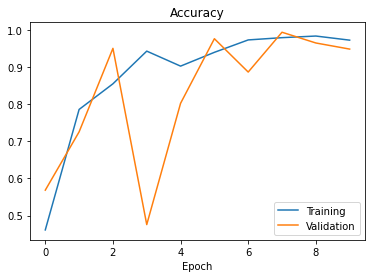

```python
plt.plot(history['accuracy'], label='Training')
plt.plot(history['val_accuracy'], label='Validation')
plt.title('Accuracy')
plt.xlabel('Epoch')
plt.legend()
plt.show()
```

```python
model.evaluate(X_test, y_test)
```

```
[0.47039681673049927, 0.8701896071434021]
```

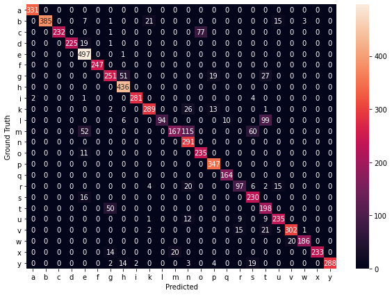

```python
y_pred = model.predict(X_test)
plot_confusion_matrix(y_test, y_pred)
```

- L => Daumen vertikal, Zeigefinger horizontal
- T => Daumen horizontal, Zeigefinger vertikal
- G => Daumen versteckt, Zeigefinger vertikal
- M, N, und S sind jeweils eine Faust mit unterschiedlicher Daumenstellung

## ResNet Conclusio

Es dauert ziemlich lange, ResNet zu trainieren. Die Trainingszeit kann durch Reduktion der Trainingsdaten verkürzt werden, allerdings besteht dann die Gefahr des Overfittings.

Trotz der wenigen Epochen und verringerter Datenmenge ist das Ergebnis passabel. Das Netzwerk ist eindeutig noch nicht fertig trainiert. Stünden mehr Ressourchen zur Verfügung, könnte es zu einem hervorragenden Ergebnis führen.